# Nudge Data

Sydney Sorkin

## Data

There were 216 total responses. Of those particpants 185 answered they are not a recruited athlete and 20 answered they are a recruited athlete. Particpants were randomly selected to recieve the intervention. Of all 216 participants 109 people were in the control group. They answered this question: “In your opinion, how difficult is it for recruited athletes to be admitted to Harvard compared to other prospective students?”. I coded the following answers: (-2) Much easier, (-1) slightly easier, (0) no difference, (1) slightly harder, (2) much harder.

107 people recieved the intervention. They received this blurb before answering the same question above: “Did you know that every recruited student athlete is evaluated through an Academic Index? Harvard’s Academic Index is 220 out of 240 which equates to ~1520 SAT/ 34 ACT and 4.0 GPA. Ivy League rules state that Harvard Athletics must have an average no lower than one standard deviation below 220.”

## Results

*For data analysis I excluded respondents who indicated they are a recruited athlete*

The mean response for the control group is -1.255102. This means the control group tended to answer “Slightly Easier”.

The mean response for the treated group is -1.2758621. The treated group also tended to answer “Slightly Easier”. The difference between the control and treated group is -0.02076. This indicates the intervention may have backfired, causing respondents to answer more negatively (towards “Much Easier”).

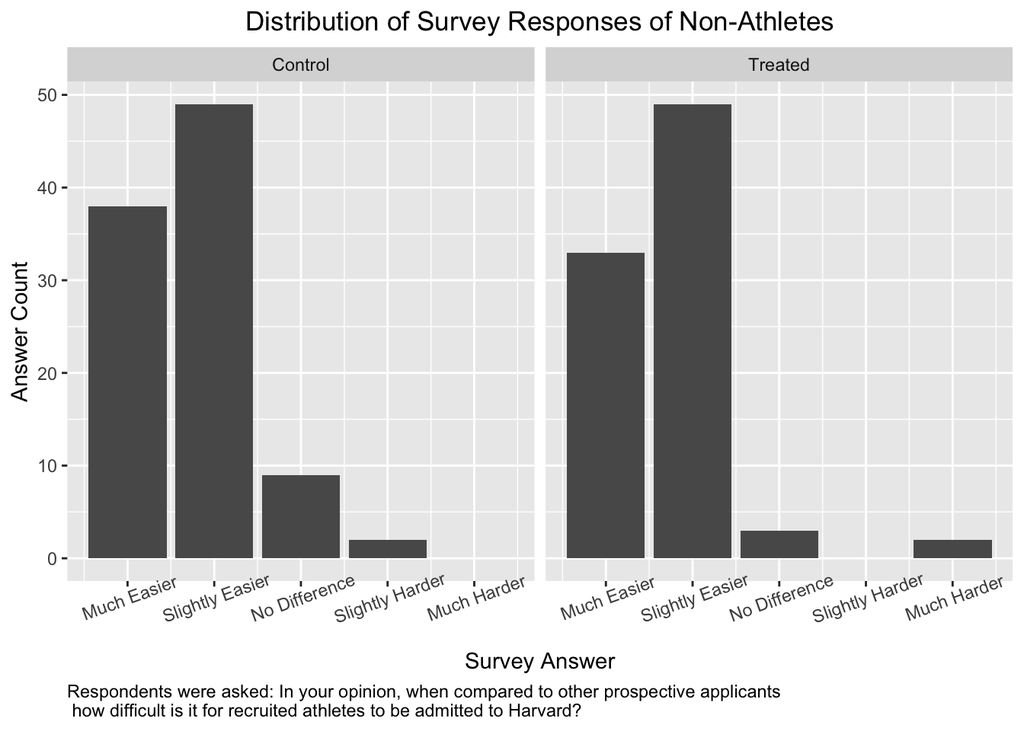